# Exercício: SARIMA no comércio varejista brasileiro

- Mostrar o código
- Esconder o código
- Ver o código fonte

UF: Pernambuco · PMC/IBGE, varejo ampliado, índice de volume sem ajuste sazonal

Autor

Gustavo Jurema

## Sobre o exercício

A base é a **PMC** (Pesquisa Mensal do Comércio) do IBGE: índice de volume de vendas no **comércio varejista ampliado** (inclui veículos e materiais de construção), por **Unidade da Federação**, mensal de jan/2004 em diante. Base 2022 = 100, **sem ajuste sazonal**.

Roteiro aplicado a **Pernambuco**:

1. Análise descritiva (linha, ACF, PACF, diferenciação) e diagnóstico de tendência/sazonalidade.
2. Testes de raiz unitária (ADF, KPSS) e estimativa de `ndiffs`.
3. Ajuste de SARIMA via `AutoARIMA(season_length=12)`.
4. Diagnóstico dos resíduos.
5. Previsão de 24 meses à frente, com intervalos de 80% e 95%.
6. Discussão dos resultados.

## Setup

**Código**

```python
import warnings

import numpy as np
import pandas as pd
import matplotlib.pyplot as plt

from statsmodels.tsa.stattools import adfuller, kpss
from statsmodels.graphics.tsaplots import plot_acf, plot_pacf
from statsmodels.stats.diagnostic import acorr_ljungbox
from statsmodels.tools.sm_exceptions import InterpolationWarning

from statsforecast import StatsForecast
from statsforecast.models import AutoARIMA, ARIMA
from statsforecast.arima import ndiffs, nsdiffs

warnings.filterwarnings("ignore", category=InterpolationWarning)
plt.rcParams.update({"axes.spines.top": False, "axes.spines.right": False, "axes.grid": True, "grid.alpha": 0.3})
```

## Carregando a base PMC

A base já foi pré-processada para conter apenas as colunas relevantes, e já no formato “long” (uma linha por data + UF). O nome da coluna de data é “data”, e a coluna de interesse (índice de volume) é “volume_idx”. A coluna “uf” indica a Unidade da Federação.

**Código**

```python
pmc = pd.read_csv("https://github.com/padsInsper/202634-fa/releases/download/data/pmc_volume_uf.csv")
pmc.head()
```

|  | uf | data | volume_idx |
| --- | --- | --- | --- |
| 0 | Acre | 2004-01-01 | 18.16706 |
| 1 | Acre | 2004-02-01 | 17.24721 |
| 2 | Acre | 2004-03-01 | 20.77331 |
| 3 | Acre | 2004-04-01 | 19.24022 |
| 4 | Acre | 2004-05-01 | 21.46320 |

## Escolha sua UF

**Código**

```python
MINHA_UF = "Pernambuco"

df_sf = (
    pmc.query("uf == @MINHA_UF")
    .rename(columns={"uf": "unique_id", "data": "ds", "volume_idx": "y"})
    [["unique_id", "ds", "y"]]
    .assign(ds=lambda d: pd.to_datetime(d["ds"]))
    .sort_values("ds")
    .reset_index(drop=True)
)

y = df_sf.set_index("ds")["y"].asfreq("MS")

print(f"Período: {y.index.min():%m/%Y} a {y.index.max():%m/%Y} · {len(y)} meses · {y.isna().sum()} faltantes")
df_sf.head()
```

```
Período: 01/2004 a 02/2026 · 266 meses · 0 faltantes
```

|  | unique_id | ds | y |
| --- | --- | --- | --- |
| 0 | Pernambuco | 2004-01-01 | 44.45615 |
| 1 | Pernambuco | 2004-02-01 | 41.08826 |
| 2 | Pernambuco | 2004-03-01 | 47.24669 |
| 3 | Pernambuco | 2004-04-01 | 44.35993 |
| 4 | Pernambuco | 2004-05-01 | 47.92027 |

## Análise descritiva

### Série no tempo

**Código**

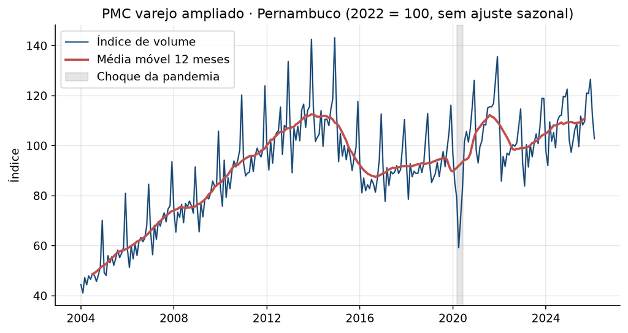

```python
fig, ax = plt.subplots()
ax.plot(y.index, y, lw=1.2, color="#1f4e79", label="Índice de volume")
ax.plot(y.index, y.rolling(12, center=True).mean(), lw=2, color="#c0504d", label="Média móvel 12 meses")
ax.axvspan(pd.Timestamp("2020-03-01"), pd.Timestamp("2020-06-01"), color="grey", alpha=0.2, label="Choque da pandemia")
ax.set_title(f"PMC varejo ampliado · {MINHA_UF} (2022 = 100, sem ajuste sazonal)")
ax.set_ylabel("Índice")
ax.legend(loc="upper left")
plt.show()
```

A série tem **tendência** clara e não constante: sobe até 2014, cai na recessão de 2015-2016, fica de lado até 2019, tem o vale da pandemia em abril/2020 e retoma depois. Por cima disso há um **padrão sazonal forte**, com pico todo dezembro.

### Perfil sazonal

**Código**

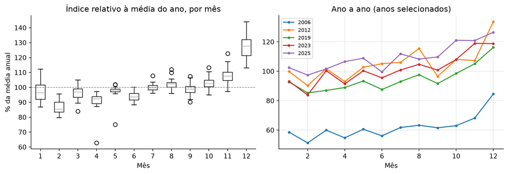

| mes | 1 | 2 | 3 | 4 | 5 | 6 | 7 | 8 | 9 | 10 | 11 | 12 |
| --- | --- | --- | --- | --- | --- | --- | --- | --- | --- | --- | --- | --- |
| média (% da média anual) | 97.2 | 86.6 | 96.5 | 90.8 | 97.3 | 93.8 | 100.1 | 102.1 | 98.8 | 103.1 | 107.9 | 126.5 |

```python
saz = df_sf.assign(mes=df_sf["ds"].dt.month, ano=df_sf["ds"].dt.year)
# remove o nível de cada ano para isolar o efeito do mês
saz["rel"] = saz["y"] / saz.groupby("ano")["y"].transform("mean") * 100

fig, axes = plt.subplots(1, 2, figsize=(11, 4))
saz.boxplot(column="rel", by="mes", ax=axes[0], grid=False)
axes[0].axhline(100, color="grey", lw=0.8, ls="--")
axes[0].set_title("Índice relativo à média do ano, por mês")
axes[0].set_xlabel("Mês"); axes[0].set_ylabel("% da média anual")

for ano, g in saz.groupby("ano"):
    if ano in (2006, 2012, 2019, 2023, 2025):
        axes[1].plot(g["mes"], g["y"], marker="o", ms=3, label=ano)
axes[1].set_title("Ano a ano (anos selecionados)")
axes[1].set_xlabel("Mês"); axes[1].legend(fontsize=8)
plt.suptitle("")
plt.tight_layout(); plt.show()

saz.groupby("mes")["rel"].mean().round(1).to_frame("média (% da média anual)").T
```

Dezembro fica cerca de 25% acima da média do ano (Natal e 13º salário) e fevereiro é o mês mais fraco (mês curto e Carnaval). O formato se repete em todos os anos, só muda o nível: sazonalidade **estável e multiplicativa leve**.

### ACF e PACF da série original

**Código**

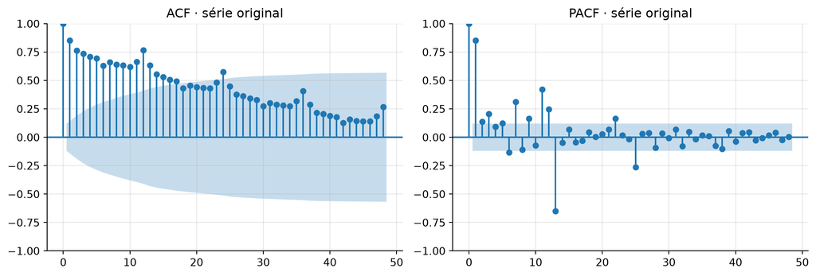

```python
fig, axes = plt.subplots(1, 2, figsize=(11, 3.8))
plot_acf(y, lags=48, ax=axes[0], title="ACF · série original")
plot_pacf(y, lags=48, ax=axes[1], method="ywm", title="PACF · série original")
plt.tight_layout(); plt.show()
```

### Diferenciação

**Código**

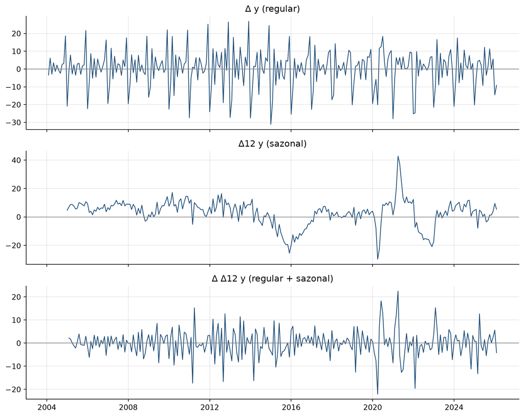

```python
dy = y.diff().dropna()                 # diferença regular (1 - B)
d12 = y.diff(12).dropna()              # diferença sazonal (1 - B^12)
d1d12 = y.diff(12).diff().dropna()     # as duas: (1 - B)(1 - B^12)

fig, axes = plt.subplots(3, 1, figsize=(10, 8), sharex=True)
for ax, s, t in zip(axes, [dy, d12, d1d12], ["Δ y (regular)", "Δ12 y (sazonal)", "Δ Δ12 y (regular + sazonal)"]):
    ax.plot(s.index, s, lw=1, color="#1f4e79")
    ax.axhline(0, color="grey", lw=0.8)
    ax.set_title(t)
plt.tight_layout(); plt.show()
```

**Código**

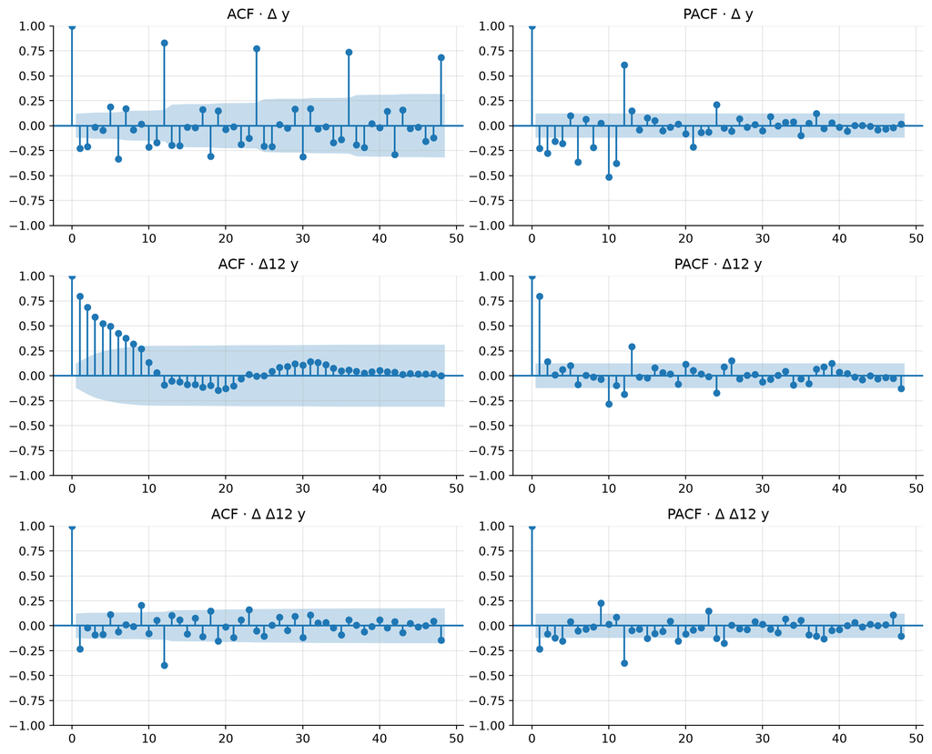

```python
fig, axes = plt.subplots(3, 2, figsize=(11, 9))
for i, (s, t) in enumerate([(dy, "Δ y"), (d12, "Δ12 y"), (d1d12, "Δ Δ12 y")]):
    plot_acf(s, lags=48, ax=axes[i, 0], title=f"ACF · {t}")
    plot_pacf(s, lags=48, ax=axes[i, 1], method="ywm", title=f"PACF · {t}")
plt.tight_layout(); plt.show()
```

- **Só Δ y**: some a tendência, mas a ACF continua com picos enormes em 12, 24, 36… A sazonalidade segue lá.
- **Só Δ12 y**: tira a sazonalidade, mas a ACF ainda decai devagar nos primeiros lags (sobra persistência de nível).
- **Δ Δ12 y**: série em torno de zero; a ACF tem pico negativo no lag 1 e no lag 12 e pouca coisa além disso. Esse padrão é o “modelo das companhias aéreas”: MA(1) regular e MA(1) sazonal sobre (1,1)×(1,1).

## Testes de raiz unitária

ADF: H0 = **tem** raiz unitária (não estacionária). KPSS: H0 = **é** estacionária. As duas hipóteses são opostas, então a conclusão é firme quando os dois concordam.

**Código**

```python
def testes(serie, nome):
    adf_p = adfuller(serie, autolag="AIC")[1]
    kpss_p = kpss(serie, regression="c", nlags="auto")[1]
    return {
        "série": nome,
        "ADF p-valor": round(adf_p, 4),
        "KPSS p-valor": round(kpss_p, 4),
        "conclusão": "estacionária" if (adf_p < 0.05 and kpss_p > 0.05)
                     else "não estacionária" if (adf_p >= 0.05 and kpss_p <= 0.05)
                     else "inconclusivo",
    }

tab = pd.DataFrame([
    testes(y, "original"),
    testes(dy, "Δ y"),
    testes(d12, "Δ12 y"),
    testes(d1d12, "Δ Δ12 y"),
])
tab
```

|  | série | ADF p-valor | KPSS p-valor | conclusão |
| --- | --- | --- | --- | --- |
| 0 | original | 0.2287 | 0.01 | não estacionária |
| 1 | Δ y | 0.0011 | 0.10 | estacionária |
| 2 | Δ12 y | 0.0046 | 0.10 | estacionária |
| 3 | Δ Δ12 y | 0.0000 | 0.10 | estacionária |

O KPSS da statsmodels só tabela p-valores entre 0,01 e 0,10: “0,01” significa “≤ 0,01” e “0,1” significa “≥ 0,10”.

**Código**

```python
d_reg = ndiffs(y.values, test="kpss")
d_saz = nsdiffs(y.values, period=12)
d_reg_apos_saz = ndiffs(d12.values, test="kpss")

print(f"ndiffs (regular, KPSS) na série original:      {d_reg}")
print(f"nsdiffs (sazonal, teste de força sazonal):      {d_saz}")
print(f"ndiffs depois da diferença sazonal:             {d_reg_apos_saz}")
```

```
ndiffs (regular, KPSS) na série original:      1
nsdiffs (sazonal, teste de força sazonal):      1
ndiffs depois da diferença sazonal:             1
```

Na série original, ADF não rejeita a raiz unitária e KPSS rejeita a estacionariedade: **não estacionária**. Depois da diferença sazonal, o KPSS ainda diz que falta uma diferença regular. A combinação **d = 1, D = 1** é a indicada, e é a mesma que o AutoARIMA escolhe abaixo.

## Modelagem

**Código**

```python
sf = StatsForecast(models=[AutoARIMA(season_length=12)], freq="MS", n_jobs=1)
sf.fit(df_sf)

modelo = sf.fitted_[0, 0].model_
p, q, P, Q, m, d, D = modelo["arma"]
print(f"Modelo escolhido: SARIMA({p},{d},{q})({P},{D},{Q})[{m}]")
print(f"AICc = {modelo['aicc']:.1f} · sigma² = {modelo['sigma2']:.2f}")

coefs = pd.Series(modelo["coef"]).to_frame("coeficiente")
var = np.diag(modelo["var_coef"])
coefs["erro padrão"] = np.sqrt(var)
coefs["z"] = coefs["coeficiente"] / coefs["erro padrão"]
coefs.round(3)
```

```
Modelo escolhido: SARIMA(1,1,1)(0,1,2)[12]
AICc = 1518.7 · sigma² = 22.29
```

|  | coeficiente | erro padrão | z |
| --- | --- | --- | --- |
| ar1 | 0.424 | 0.052 | 8.235 |
| ma1 | -0.707 | 0.063 | -11.251 |
| sma1 | -0.649 | 0.063 | -10.317 |
| sma2 | -0.097 | 0.063 | -1.537 |

O AutoARIMA escolheu **SARIMA(1,1,1)(0,1,2)[12]**:

- **d = 1 e D = 1**: uma diferença regular (tendência) e uma sazonal (padrão anual). Bate com ADF/KPSS e com `ndiffs`/`nsdiffs`.
- **MA(1) regular negativo e forte** (≈ −0,71) e **SMA(1) negativo** (≈ −0,65): são os picos negativos no lag 1 e no lag 12 da ACF de Δ Δ12 y.
- **AR(1)** (≈ 0,42) compensa parte da sobrediferenciação. O SMA(2) é pequeno (≈ −0,10, |z| ≈ 1,5) e não é significativo a 5%: é um ajuste fino.

### Comparação com o “modelo das companhias aéreas”

Teste rápido: o SARIMA(0,1,1)(0,1,1)[12], que a ACF diferenciada sugeria a olho, perde para o modelo escolhido?

**Código**

```python
sf_air = StatsForecast(models=[ARIMA(order=(0, 1, 1), seasonal_order=(0, 1, 1), season_length=12, alias="Airline")], freq="MS")
sf_air.fit(df_sf)
air = sf_air.fitted_[0, 0].model_
pd.DataFrame({
    "modelo": ["AutoARIMA (1,1,1)(0,1,2)", "Airline (0,1,1)(0,1,1)"],
    "AICc": [round(modelo["aicc"], 1), round(air["aicc"], 1)],
})
```

|  | modelo | AICc |
| --- | --- | --- |
| 0 | AutoARIMA (1,1,1)(0,1,2) | 1518.7 |
| 1 | Airline (0,1,1)(0,1,1) | 1522.5 |

O AutoARIMA fica cerca de 4 pontos de AICc abaixo do airline: o AR(1) ajuda, mas a estrutura de base é a mesma que a leitura da ACF sugeria.

## Diagnóstico dos resíduos

**Código**

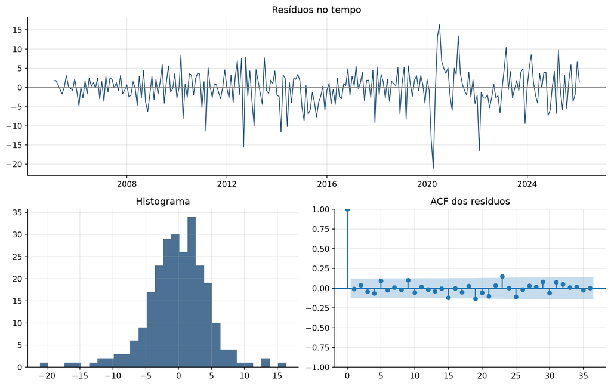

```python
res = pd.Series(modelo["residuals"], index=y.index)
res_util = res.iloc[13:]   # descarta o período "queimado" pelas diferenças (1 + 12)

fig = plt.figure(figsize=(11, 7))
ax1 = fig.add_subplot(2, 1, 1)
ax1.plot(res_util.index, res_util, lw=1, color="#1f4e79")
ax1.axhline(0, color="grey", lw=0.8)
ax1.set_title("Resíduos no tempo")
ax2 = fig.add_subplot(2, 2, 3)
ax2.hist(res_util, bins=30, color="#1f4e79", alpha=0.8)
ax2.set_title("Histograma")
ax3 = fig.add_subplot(2, 2, 4)
plot_acf(res_util, lags=36, ax=ax3, title="ACF dos resíduos")
plt.tight_layout(); plt.show()
```

**Código**

```python
lb = acorr_ljungbox(res_util, lags=[12, 24, 36], model_df=p + q + P + Q)
lb.round(3)
```

|  | lb_stat | lb_pvalue |
| --- | --- | --- |
| 12 | 8.191 | 0.415 |
| 24 | 28.641 | 0.095 |
| 36 | 38.093 | 0.212 |

**Código**

```python
print("Maiores resíduos em valor absoluto:")
res_util.abs().sort_values(ascending=False).head(5).round(1)
```

```
Maiores resíduos em valor absoluto:
```

```
ds
2020-04-01    21.1
2022-02-01    16.4
2020-07-01    16.3
2012-09-01    15.5
2020-03-01    13.5
dtype: float64
```

O teste de Ljung-Box não rejeita ruído branco a 5% em 12, 24 e 36 defasagens, e a ACF dos resíduos não mostra picos em 12 ou 24: **não sobra sazonalidade**. Três dos cinco maiores resíduos são de 2020 (fechamento do comércio em março/abril e reabertura em julho). Esses meses deixam o histograma com caudas mais pesadas que a normal, o que faz os intervalos de previsão serem um pouco otimistas.

## Previsão · 24 meses à frente

**Código**

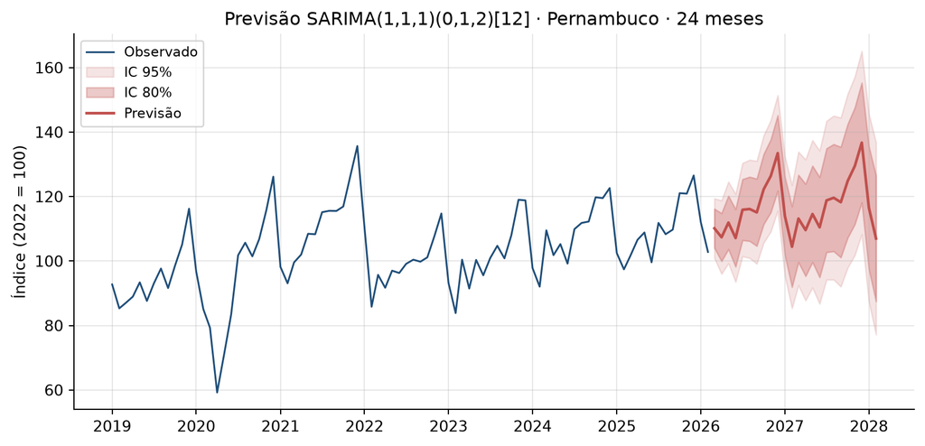

```python
H = 24
prev = sf.predict(h=H, level=[80, 95])

hist = df_sf[df_sf["ds"] >= "2019-01-01"]
fig, ax = plt.subplots(figsize=(10, 4.5))
ax.plot(hist["ds"], hist["y"], color="#1f4e79", lw=1.2, label="Observado")
ax.fill_between(prev["ds"], prev["AutoARIMA-lo-95"], prev["AutoARIMA-hi-95"], color="#c0504d", alpha=0.15, label="IC 95%")
ax.fill_between(prev["ds"], prev["AutoARIMA-lo-80"], prev["AutoARIMA-hi-80"], color="#c0504d", alpha=0.30, label="IC 80%")
ax.plot(prev["ds"], prev["AutoARIMA"], color="#c0504d", lw=1.8, label="Previsão")
ax.set_title(f"Previsão SARIMA({p},{d},{q})({P},{D},{Q})[12] · {MINHA_UF} · {H} meses")
ax.set_ylabel("Índice (2022 = 100)")
ax.legend(loc="upper left", fontsize=9)
plt.show()
```

**Código**

```python
tab_prev = prev.drop(columns="unique_id").assign(ds=lambda d: d["ds"].dt.strftime("%m/%Y"))
tab_prev["amplitude IC 95%"] = tab_prev["AutoARIMA-hi-95"] - tab_prev["AutoARIMA-lo-95"]
tab_prev.round(1).set_index("ds")
```

| ds | AutoARIMA | AutoARIMA-lo-95 | AutoARIMA-lo-80 | AutoARIMA-hi-80 | AutoARIMA-hi-95 | amplitude IC 95% |
| --- | --- | --- | --- | --- | --- | --- |
| 03/2026 | 110.1 | 100.9 | 104.1 | 116.2 | 119.4 | 18.5 |
| 04/2026 | 107.4 | 96.0 | 99.9 | 114.8 | 118.8 | 22.8 |
| 05/2026 | 111.9 | 99.3 | 103.6 | 120.2 | 124.6 | 25.3 |
| 06/2026 | 107.1 | 93.5 | 98.2 | 116.0 | 120.8 | 27.3 |
| 07/2026 | 115.9 | 101.4 | 106.4 | 125.4 | 130.4 | 28.9 |
| 08/2026 | 116.1 | 100.9 | 106.2 | 126.1 | 131.4 | 30.5 |
| 09/2026 | 115.1 | 99.1 | 104.7 | 125.5 | 131.0 | 31.9 |
| 10/2026 | 122.3 | 105.6 | 111.4 | 133.1 | 138.9 | 33.3 |
| 11/2026 | 126.4 | 109.1 | 115.1 | 137.7 | 143.7 | 34.6 |
| 12/2026 | 133.5 | 115.5 | 121.7 | 145.2 | 151.4 | 35.8 |
| 01/2027 | 114.0 | 95.4 | 101.9 | 126.1 | 132.5 | 37.0 |
| 02/2027 | 104.4 | 85.3 | 91.9 | 116.9 | 123.5 | 38.2 |
| 03/2027 | 113.2 | 92.5 | 99.6 | 126.7 | 133.9 | 41.4 |
| 04/2027 | 109.6 | 87.7 | 95.3 | 123.9 | 131.5 | 43.7 |
| 05/2027 | 114.6 | 91.7 | 99.6 | 129.5 | 137.4 | 45.7 |
| 06/2027 | 110.5 | 86.7 | 94.9 | 126.0 | 134.2 | 47.5 |
| 07/2027 | 118.8 | 94.2 | 102.7 | 134.9 | 143.4 | 49.2 |
| 08/2027 | 119.6 | 94.2 | 103.0 | 136.2 | 145.0 | 50.8 |
| 09/2027 | 118.2 | 92.0 | 101.1 | 135.4 | 144.4 | 52.4 |
| 10/2027 | 124.8 | 97.9 | 107.2 | 142.5 | 151.8 | 53.9 |
| 11/2027 | 129.5 | 101.8 | 111.4 | 147.6 | 157.2 | 55.4 |
| 12/2027 | 136.7 | 108.3 | 118.1 | 155.3 | 165.1 | 56.8 |
| 01/2028 | 116.5 | 87.4 | 97.5 | 135.5 | 145.6 | 58.2 |
| 02/2028 | 107.0 | 77.2 | 87.5 | 126.5 | 136.8 | 59.6 |

**Código**

```python
ult12 = y.iloc[-12:].mean()
prox12 = prev["AutoARIMA"].iloc[:12].mean()
seg12 = prev["AutoARIMA"].iloc[12:].mean()
print(f"Média dos últimos 12 meses observados:  {ult12:.1f}")
print(f"Média prevista para os próximos 12:     {prox12:.1f}  ({prox12 / ult12 - 1:+.1%})")
print(f"Média prevista para os 12 seguintes:    {seg12:.1f}  ({seg12 / prox12 - 1:+.1%})")
```

```
Média dos últimos 12 meses observados:  110.8
Média prevista para os próximos 12:     115.3  (+4.1%)
Média prevista para os 12 seguintes:    118.2  (+2.5%)
```

### Comparação com outras UFs

**Código**

```python
def resumo_uf(uf):
    d = (pmc.query("uf == @uf")
         .rename(columns={"uf": "unique_id", "data": "ds", "volume_idx": "y"})
         .assign(ds=lambda x: pd.to_datetime(x["ds"])))
    sf_uf = StatsForecast(models=[AutoARIMA(season_length=12)], freq="MS")
    sf_uf.fit(d)
    mod = sf_uf.fitted_[0, 0].model_
    p_, q_, P_, Q_, _, d_, D_ = mod["arma"]
    yy = d["y"].values
    rel = d.assign(ano=d["ds"].dt.year, mes=d["ds"].dt.month)
    rel["r"] = rel["y"] / rel.groupby("ano")["y"].transform("mean")
    return {
        "UF": uf,
        "modelo": f"({p_},{d_},{q_})({P_},{D_},{Q_})[12]",
        "cresc. médio a.a.": f"{(yy[-12:].mean() / yy[:12].mean()) ** (12 / (len(yy) - 12)) - 1:.1%}",
        "dezembro / média do ano": round(rel.groupby("mes")["r"].mean()[12], 2),
        "desvio do choque / nível": round(np.sqrt(mod["sigma2"]) / yy[-12:].mean(), 3),
    }

pd.DataFrame([resumo_uf(u) for u in
              ["Pernambuco", "São Paulo", "Goiás", "Mato Grosso", "Tocantins", "Roraima", "Amapá"]]).set_index("UF")
```

| UF | modelo | cresc. médio a.a. | dezembro / média do ano | desvio do choque / nível |
| --- | --- | --- | --- | --- |
| Pernambuco | (1,1,1)(0,1,2)[12] | 4.0% | 1.26 | 0.043 |
| São Paulo | (2,1,1)(0,1,1)[12] | 2.7% | 1.21 | 0.040 |
| Goiás | (0,1,1)(1,1,1)[12] | 3.4% | 1.15 | 0.046 |
| Mato Grosso | (3,0,0)(0,1,2)[12] | 4.5% | 1.17 | 0.032 |
| Tocantins | (2,0,2)(1,1,1)[12] | 8.7% | 1.18 | 0.046 |
| Roraima | (2,0,1)(0,1,1)[12] | 7.4% | 1.19 | 0.031 |
| Amapá | (1,0,0)(2,1,0)[12] | 5.7% | 1.27 | 0.049 |

## Discussão

**1. Sazonalidade e tendência no ACF/PACF.** Sim para as duas. A ACF da série original decai muito devagar, sinal de tendência estocástica, e tem morros nos lags 12, 24, 36 e 48, sinal de sazonalidade anual. Bate com o gráfico de linha: nível que sobe, cai em 2015-16 e retoma, e um pico de dezembro que se repete todo ano.

**2. Diferenças e componentes AR/MA.** O AutoARIMA aplicou **uma diferença regular e uma sazonal** (d = 1, D = 1), a mesma conclusão de ADF/KPSS, `ndiffs` e `nsdiffs`. Escolheu AR(1), MA(1) e SMA(2). Os picos negativos nos lags 1 e 12 da ACF de Δ Δ12 y já apontavam para MA(1) e SMA(1). O AR(1) e o segundo termo sazonal são ajustes finos: o modelo “airline” (0,1,1)(0,1,1) fica só cerca de 4 pontos de AICc atrás.

**3. Resíduos.** Se comportam como ruído branco: Ljung-Box não rejeita em 12, 24 e 36 defasagens e não há pico sazonal remanescente na ACF. Há dois pontos fracos. O choque da pandemia em 2020 gera resíduos extremos e caudas pesadas, que o SARIMA trata como choques aleatórios comuns. E a variância dos resíduos é visivelmente maior de 2020 em diante do que antes: o modelo assume variância constante, então os intervalos de previsão tendem a ser estreitos demais.

**4. Previsão.** Visualmente razoável. Reproduz o pico de dezembro e o vale de fevereiro, começa ancorada no nível recente e projeta uma tendência suave de alta, herdada da combinação d = 1 + D = 1. Os intervalos abrem bastante com o horizonte, porque com duas diferenças a incerteza se acumula. No segundo ano a faixa de 95% fica larga demais para orientar decisão; o primeiro ano é a parte útil.